# Prediccion de Tipo de Transporte - Modelo SVM - Kernel Simoide - Proyecto de Transporte

### General: Objetivos del Proyecto y Definición de Variables

El objetivo principal de este proyecto es desarrollar un modelo basado en **Máquinas de Vectores de Soporte (SVM)** para predecir el **modo de transporte** utilizado por un individuo en función de los datos recopilados por sensores de dispositivos móviles. Se busca analizar cómo las diferentes señales captadas por el acelerómetro, giróscopo, barómetro, GPS y magnetómetro pueden ser utilizadas para inferir con precisión el medio de transporte en uso.

Para lograr esto, se cuenta con un conjunto de datos que incluye:

1. **Registro Temporal**
   - Cada observación está asociada a un instante de tiempo específico.
2. **Datos de Movimiento y Orientación**
   - **Acelerómetro**: Componentes X, Y, Z del vector aceleración.
   - **Giróscopo**: Velocidad angular en los ejes X, Y, Z y su derivada.
   - **Matriz de Rotación y Cuaterniones**: Representan la orientación tridimensional del dispositivo.
3. **Datos de Ubicación y Contexto**
   - **GPS**: Coordenadas de latitud y longitud, velocidad, altitud y rumbo.
   - **Presión Atmosférica**: Valores obtenidos del barómetro, junto con la altitud relativa.
   - **Campo Magnético Terrestre**: Medición en los ejes X, Y, Z.
4. **Variables Categóricas**
   - **Modo de Transporte**: La categoría que se busca predecir (caminar, bicicleta, automóvil, etc.).
   - **Nivel de Confianza**: Un indicador de la precisión estimada para la clasificación del transporte en los datos originales.

### Objetivo Notebook:

- Evaluar el rendimiento del modelo Support Vector Machine (SVM) con diferentes configuraciones del kernel Simoidal.
- Optimizar el modelo SVM mediante la búsqueda de hiperparámetros.
- Generar predicciones utilizando el conjunto de test 1.

# **1. Carga de librerías**

```r
# Lista de paquetes necesarios
necessary_packages <- c("dplyr", "caret", "e1071", "robustbase", "ggplot2", "data.table", "pROC","doParallel")

# Instalar paquetes que no están instalados
new_packages <- necessary_packages[!(necessary_packages %in% installed.packages()[, "Package"])]
if (length(new_packages) > 0) {
  install.packages(new_packages)
}

# Cargar todos los paquetes
lapply(necessary_packages, library, character.only = TRUE)
```

[output not shown]

```r
# Cargar las librerías necesarias
library(caret)      # Para división estratificada y evaluación de modelos
library(scales)     # Para Min-Max Scaling
library(e1071)      # Para entrenar SVM
library(randomForest)  # Para obtener la importancia de las variables
library(dplyr)      # Para manipulación de datos
# Cargar la librería
library(visdat)
# Cargar la librería
library(tidyr)
# Cargar el paquete 'car'
library(car)
library(ggplot2)
library(stringr) #Cambiar variables
```

# 2. Cargar el dataset

```r
# Ruta del archivo CSV (modificar según tu sistema)
ruta_dataset <- "C:/Users/ngonzalez/Documents/Inesdi/Datos proyecto 8/proyect8/data_vars_imputadas.csv"
data <- read.csv(ruta_dataset)


data <- read.csv(ruta_dataset)

# Resumen del dataset
cat("### Información General del Dataset")
```

```
### Información General del Dataset
```

```r
dim(data) # Dimensiones del dataset
```

```
[1] 25491    25
```

```r
str(data) # Estructura del dataset
```

```
'data.frame':   25491 obs. of  25 variables:
 $ accelX.g.               : num  0.0437 0.0405 -0.1734 0.1984 -0.0991 ...
 $ accelY.g.               : num  -0.625 -0.636 -0.308 -0.417 -0.652 ...
 $ accelZ.g.               : num  -0.7299 -0.7556 -0.0805 -1.0315 -0.8322 ...
 $ accelUserX.g.           : num  0.0137 0.0119 -0.1732 -0.0111 -0.1217 ...
 $ accelUserY.g.           : num  0.0009 -0.0026 0.3564 0.1551 -0.2809 ...
 $ accelUserZ.g.           : num  0.058 0.0242 0.6277 -0.2601 0.091 ...
 $ gyroX.rad.s.            : num  0.0985 -0.0539 -0.1249 -1.0331 0.4942 ...
 $ gyroY.rad.s.            : num  0.0902 0.0716 0.0633 1.0555 0.2636 ...
 $ gyroZ.rad.s.            : num  -0.0039 -0.1416 -0.021 -1.2428 -1.5661 ...
 $ Roll.rads.              : num  0.0347 0.0338 -0.009 0.3746 0.0522 ...
 $ Pitch.rads.             : num  0.681 0.68 0.713 0.385 0.384 ...
 $ Yaw.rads.               : num  -0.0248 2.1585 2.1856 1.9195 1.8733 ...
 $ m11                     : num  1 -0.572 -0.572 -0.447 -0.316 ...
 $ m12                     : num  -0.0029 0.82 0.8203 0.8277 0.9475 ...
 $ m13                     : num  -0.0269 -0.0263 0.0068 -0.3391 -0.0483 ...
 $ m21                     : num  0.0192 -0.647 -0.6179 -0.871 -0.8851 ...
 $ m22                     : num  0.776 -0.431 -0.436 -0.317 -0.276 ...
 $ m23                     : num  0.63 0.629 0.654 0.376 0.375 ...
 $ m31                     : num  0.0191 0.5044 0.5396 0.2034 0.3416 ...
 $ m32                     : num  -0.63 0.377 0.37 0.463 0.161 ...
 $ m33                     : num  0.776 0.777 0.756 0.863 0.926 ...
 $ ActivityType            : chr  "Coche_autopista" "Coche_autopista" "Coche_autopista" "Coche_autopista" ...
 $ Pressure.kilopascals.   : num  97.1 97.1 97.1 97.1 97.1 ...
 $ RelativeAltitude.meters.: num  -0.214 -0.214 -0.214 -0.214 -0.214 ...
 $ herzios                 : int  2 2 2 2 2 2 2 2 2 2 ...
```

```r
summary(data) # Resumen estadístico básico
```

```
   accelX.g.          accelY.g.         accelZ.g.       accelUserX.g.       accelUserY.g.       accelUserZ.g.        gyroX.rad.s.       gyroY.rad.s.        gyroZ.rad.s.         Roll.rads.
 Min.   :-0.85820   Min.   :-1.0336   Min.   :-1.6804   Min.   :-0.683400   Min.   :-0.409300   Min.   :-0.763000   Min.   :-2.97000   Min.   :-4.737200   Min.   :-6.740700   Min.   :-0.8404
 1st Qu.:-0.07185   1st Qu.:-0.0105   1st Qu.:-0.9862   1st Qu.:-0.016600   1st Qu.:-0.034550   1st Qu.:-0.019000   1st Qu.:-0.06305   1st Qu.:-0.026650   1st Qu.:-0.020700   1st Qu.:-0.0609
 Median :-0.00180   Median : 0.0707   Median :-0.9602   Median :-0.001300   Median :-0.008600   Median : 0.010700   Median :-0.03020   Median : 0.005000   Median :-0.008200   Median : 0.0089
 Mean   : 0.02337   Mean   : 0.1015   Mean   :-0.7595   Mean   : 0.003747   Mean   :-0.004326   Mean   : 0.007049   Mean   :-0.02769   Mean   : 0.002209   Mean   :-0.006238   Mean   : 0.1529
 3rd Qu.: 0.07310   3rd Qu.: 0.2398   3rd Qu.:-0.7732   3rd Qu.: 0.019800   3rd Qu.: 0.024500   3rd Qu.: 0.032700   3rd Qu.: 0.01320   3rd Qu.: 0.047650   3rd Qu.: 0.006400   3rd Qu.: 0.0634
 Max.   : 2.08900   Max.   : 1.0647   Max.   : 0.9785   Max.   : 1.441200   Max.   : 1.063900   Max.   : 1.262000   Max.   : 5.01590   Max.   : 6.693200   Max.   : 4.885300   Max.   : 2.8364
  Pitch.rads.        Yaw.rads.            m11               m12               m13                m21               m22               m23               m31               m32
 Min.   :-0.9552   Min.   :-3.1416   Min.   :-0.9989   Min.   :-0.9997   Min.   :-0.95190   Min.   :-0.9830   Min.   :-0.9999   Min.   :-0.8164   Min.   :-0.9756   Min.   :-0.74720
 1st Qu.:-0.2693   1st Qu.:-2.0061   1st Qu.:-0.7109   1st Qu.:-0.7037   1st Qu.:-0.06320   1st Qu.:-0.3786   1st Qu.:-0.7375   1st Qu.:-0.2661   1st Qu.:-0.4123   1st Qu.:-0.11020
 Median :-0.0828   Median :-0.4486   Median :-0.2219   Median :-0.4315   Median :-0.00880   Median : 0.4311   Median :-0.4172   Median :-0.0827   Median :-0.0066   Median :-0.02260
 Mean   :-0.1109   Mean   :-0.1836   Mean   :-0.1140   Mean   :-0.1447   Mean   :-0.02089   Mean   : 0.1656   Mean   :-0.2393   Mean   :-0.1072   Mean   :-0.1773   Mean   :-0.02027
 3rd Qu.:-0.0156   3rd Qu.: 1.5235   3rd Qu.: 0.4187   3rd Qu.: 0.4598   3rd Qu.: 0.06000   3rd Qu.: 0.7056   3rd Qu.: 0.1726   3rd Qu.:-0.0156   3rd Qu.: 0.0200   3rd Qu.: 0.04640
 Max.   : 1.4767   Max.   : 3.1415   Max.   : 1.0000   Max.   : 0.9997   Max.   : 0.72420   Max.   : 0.9997   Max.   : 0.9906   Max.   : 0.9956   Max.   : 0.9765   Max.   : 0.66420
      m33          ActivityType       Pressure.kilopascals. RelativeAltitude.meters.    herzios
 Min.   :-0.9465   Length:25491       Min.   : 96.97        Min.   :-65.9100         Min.   :  2.0
 1st Qu.: 0.7563   Class :character   1st Qu.:101.58        1st Qu.: -0.5443         1st Qu.: 50.0
 Median : 0.9894   Mode  :character   Median :102.06        Median :  9.9933         Median :100.0
 Mean   : 0.7658                      Mean   :101.73        Mean   : 15.7070         Mean   :124.5
 3rd Qu.: 0.9963                      3rd Qu.:102.53        3rd Qu.: 35.9673         3rd Qu.:250.0
 Max.   : 1.0000                      Max.   :102.57        Max.   : 38.2872         Max.   :250.0
```

## 2.1 Selección de las Variables de acuerdo a RF, VIF y Anova

```r
# Seleccionar solo las variables relevantes
data_filtrado <- data %>%
  select(accelX.g., accelZ.g., accelY.g.,  # Aceleración
         Roll.rads., Pitch.rads., Yaw.rads., gyroY.rad.s.,  # Giroscopios
         Pressure.kilopascals., herzios,  # Contexto ambiental
         m33,  # Componentes de Movimiento
         ActivityType)  # Variable objetivo

# Guardar el dataset actualizado
write.csv(data_filtrado, "dataset_filtrado.csv", row.names = FALSE)

# Mostrar primeras filas del dataset filtrado
head(data_filtrado)
```

|  | accelX.g. | accelZ.g. | accelY.g. | Roll.rads. | Pitch.rads. | Yaw.rads. | gyroY.rad.s. | Pressure.kilopascals. | herzios | m33 | ActivityType |
| --- | --- | --- | --- | --- | --- | --- | --- | --- | --- | --- | --- |
| 1 | 0.0437 | -0.7299 | -0.6249 | 0.0347 | 0.6813 | -0.0248 | 0.0902 | 97.0946 | 2 | 0.7763 | Coche_autopista |
| 2 | 0.0405 | -0.7556 | -0.6357 | 0.0338 | 0.6803 | 2.1585 | 0.0716 | 97.0946 | 2 | 0.7770 | Coche_autopista |
| 3 | -0.1734 | -0.0805 | -0.3077 | -0.0090 | 0.7131 | 2.1856 | 0.0633 | 97.0946 | 2 | 0.7563 | Coche_autopista |
| 4 | 0.1984 | -1.0315 | -0.4168 | 0.3746 | 0.3850 | 1.9195 | 1.0555 | 97.0946 | 2 | 0.8625 | Coche_autopista |
| 5 | -0.0991 | -0.8322 | -0.6518 | 0.0522 | 0.3840 | 1.8733 | 0.2636 | 97.0946 | 2 | 0.9259 | Coche_autopista |
| 6 | -0.0382 | -0.9711 | -0.2162 | 0.0116 | 0.2579 | 1.8729 | -0.3883 | 97.0948 | 2 | 0.9669 | Coche_autopista |

```r
str ( data_filtrado)
```

```
'data.frame':   25491 obs. of  11 variables:
 $ accelX.g.            : num  0.0437 0.0405 -0.1734 0.1984 -0.0991 ...
 $ accelZ.g.            : num  -0.7299 -0.7556 -0.0805 -1.0315 -0.8322 ...
 $ accelY.g.            : num  -0.625 -0.636 -0.308 -0.417 -0.652 ...
 $ Roll.rads.           : num  0.0347 0.0338 -0.009 0.3746 0.0522 ...
 $ Pitch.rads.          : num  0.681 0.68 0.713 0.385 0.384 ...
 $ Yaw.rads.            : num  -0.0248 2.1585 2.1856 1.9195 1.8733 ...
 $ gyroY.rad.s.         : num  0.0902 0.0716 0.0633 1.0555 0.2636 ...
 $ Pressure.kilopascals.: num  97.1 97.1 97.1 97.1 97.1 ...
 $ herzios              : int  2 2 2 2 2 2 2 2 2 2 ...
 $ m33                  : num  0.776 0.777 0.756 0.863 0.926 ...
 $ ActivityType         : chr  "Coche_autopista" "Coche_autopista" "Coche_autopista" "Coche_autopista" ...
```

# 3. Implementar `class.weights` combinado para ajustar el desbalance de clases.

La combinación de pesos manuales y los pesos inversos puede ser eficaz para balancear la influencia de las clases en el modelo. Los pesos manuales se basan en un conocimiento previo sobre la importancia relativa de cada clase, mientras que los pesos inversos ajustan la influencia según la frecuencia de las clases en los datos.

**Implementación de Promediado de Pesos**: Para calcular los pesos combinados, utilizamos una combinación de los pesos manuales y los inversos. Estos pesos se promedian para generar una estrategia equilibrada.

```r
# Convertir la variable objetivo a factor (si no lo está)
data_filtrado$ActivityType <- as.factor(data_filtrado$ActivityType)

# 1 Convertir Herzios a numérico
data_filtrado <- data_filtrado %>%
  mutate(herzios = as.numeric(herzios))

# Verificar que Herzios ahora es numérico
str(data_filtrado$herzios)
```

```
 num [1:25491] 2 2 2 2 2 2 2 2 2 2 ...
```

```r
summary(data_filtrado$herzios)
```

```
   Min. 1st Qu.  Median    Mean 3rd Qu.    Max.
    2.0    50.0   100.0   124.5   250.0   250.0
```

```r
# Identificar solo las columnas numéricas (excluyendo `ActivityType`)
num_cols <- sapply(data_filtrado, is.numeric)

# Aplicar Min-Max Scaling SOLO a las columnas numéricas
preproc <- preProcess(data_filtrado[, num_cols], method = c("range"))
data_scaled <- predict(preproc, data_filtrado[, num_cols])

# Volver a agregar la variable objetivo `ActivityType`
data_scaled$ActivityType <- data_filtrado$ActivityType

# Verificar la estructura del dataset escalado
str(data_scaled)
```

```
'data.frame':   25491 obs. of  11 variables:
 $ accelX.g.            : num  0.306 0.305 0.232 0.359 0.258 ...
 $ accelZ.g.            : num  0.357 0.348 0.602 0.244 0.319 ...
 $ accelY.g.            : num  0.195 0.19 0.346 0.294 0.182 ...
 $ Roll.rads.           : num  0.238 0.238 0.226 0.33 0.243 ...
 $ Pitch.rads.          : num  0.673 0.673 0.686 0.551 0.551 ...
 $ Yaw.rads.            : num  0.496 0.844 0.848 0.806 0.798 ...
 $ gyroY.rad.s.         : num  0.422 0.421 0.42 0.507 0.438 ...
 $ Pressure.kilopascals.: num  0.0231 0.0231 0.0231 0.0231 0.0231 ...
 $ herzios              : num  0 0 0 0 0 0 0 0 0 0 ...
 $ m33                  : num  0.885 0.885 0.875 0.929 0.962 ...
 $ ActivityType         : Factor w/ 6 levels "Andando","Autobus",..: 5 5 5 5 5 5 5 5 5 5 ...
```

```r
summary(data_scaled)
```

```
   accelX.g.        accelZ.g.        accelY.g.        Roll.rads.      Pitch.rads.       Yaw.rads.       gyroY.rad.s.    Pressure.kilopascals.    herzios            m33
 Min.   :0.0000   Min.   :0.0000   Min.   :0.0000   Min.   :0.0000   Min.   :0.0000   Min.   :0.0000   Min.   :0.0000   Min.   :0.0000        Min.   :0.0000   Min.   :0.0000
 1st Qu.:0.2668   1st Qu.:0.2611   1st Qu.:0.4876   1st Qu.:0.2120   1st Qu.:0.2820   1st Qu.:0.1807   1st Qu.:0.4121   1st Qu.:0.8239        1st Qu.:0.1935   1st Qu.:0.8748
 Median :0.2906   Median :0.2709   Median :0.5263   Median :0.2310   Median :0.3587   Median :0.4286   Median :0.4149   Median :0.9088        Median :0.3952   Median :0.9946
 Mean   :0.2991   Mean   :0.3463   Mean   :0.5410   Mean   :0.2702   Mean   :0.3472   Mean   :0.4708   Mean   :0.4146   Mean   :0.8496        Mean   :0.4941   Mean   :0.8797
 3rd Qu.:0.3160   3rd Qu.:0.3412   3rd Qu.:0.6069   3rd Qu.:0.2458   3rd Qu.:0.3864   3rd Qu.:0.7425   3rd Qu.:0.4186   3rd Qu.:0.9924        3rd Qu.:1.0000   3rd Qu.:0.9981
 Max.   :1.0000   Max.   :1.0000   Max.   :1.0000   Max.   :1.0000   Max.   :1.0000   Max.   :1.0000   Max.   :1.0000   Max.   :1.0000        Max.   :1.0000   Max.   :1.0000
          ActivityType
 Andando        : 4976
 Autobus        : 2679
 Avion          :  816
 Bicicleta      : 2985
 Coche_autopista: 1741
 Coche_urbano   :12294
```

```r
# Verificar si hay NA después del escalado
print("🔎 ¿Hay valores NA después del escalado?")
```

```
[1] "🔎 ¿Hay valores NA después del escalado?"
```

```r
print(any(is.na(data_scaled)))  # Debe ser FALSE
```

```
[1] FALSE
```

```r
# Verificar si las variables están en el rango correcto [0,1]
summary(data_scaled)
```

```
   accelX.g.        accelZ.g.        accelY.g.        Roll.rads.      Pitch.rads.       Yaw.rads.       gyroY.rad.s.    Pressure.kilopascals.    herzios            m33
 Min.   :0.0000   Min.   :0.0000   Min.   :0.0000   Min.   :0.0000   Min.   :0.0000   Min.   :0.0000   Min.   :0.0000   Min.   :0.0000        Min.   :0.0000   Min.   :0.0000
 1st Qu.:0.2668   1st Qu.:0.2611   1st Qu.:0.4876   1st Qu.:0.2120   1st Qu.:0.2820   1st Qu.:0.1807   1st Qu.:0.4121   1st Qu.:0.8239        1st Qu.:0.1935   1st Qu.:0.8748
 Median :0.2906   Median :0.2709   Median :0.5263   Median :0.2310   Median :0.3587   Median :0.4286   Median :0.4149   Median :0.9088        Median :0.3952   Median :0.9946
 Mean   :0.2991   Mean   :0.3463   Mean   :0.5410   Mean   :0.2702   Mean   :0.3472   Mean   :0.4708   Mean   :0.4146   Mean   :0.8496        Mean   :0.4941   Mean   :0.8797
 3rd Qu.:0.3160   3rd Qu.:0.3412   3rd Qu.:0.6069   3rd Qu.:0.2458   3rd Qu.:0.3864   3rd Qu.:0.7425   3rd Qu.:0.4186   3rd Qu.:0.9924        3rd Qu.:1.0000   3rd Qu.:0.9981
 Max.   :1.0000   Max.   :1.0000   Max.   :1.0000   Max.   :1.0000   Max.   :1.0000   Max.   :1.0000   Max.   :1.0000   Max.   :1.0000        Max.   :1.0000   Max.   :1.0000
          ActivityType
 Andando        : 4976
 Autobus        : 2679
 Avion          :  816
 Bicicleta      : 2985
 Coche_autopista: 1741
 Coche_urbano   :12294
```

```r
# Aplciar nuevos pesos
class_weights_pesado <- c("Andando" = 10, "Autobus" = 15, "Avion" = 60,
                   "Bicicleta" = 5, "Coche_autopista" = 10, "Coche_urbano" = 1)

# **2. Normalización de pesos manuales (usando el máximo en vez de la suma)**
class_weights_pesado <- class_weights_pesado / max(class_weights_pesado)
print("Pesos manuales normalizados:")
```

```
[1] "Pesos manuales normalizados:"
```

```r
print(class_weights_pesado)
```

```
        Andando         Autobus           Avion       Bicicleta Coche_autopista    Coche_urbano
     0.16666667      0.25000000      1.00000000      0.08333333      0.16666667      0.01666667
```

```r
# **3. Calcular pesos inversamente proporcionales al tamaño de cada clase**
class_counts <- table(data_scaled$ActivityType)
class_weights_auto <- 1 / class_counts  # Inversamente proporcional al número de muestras

# **4. Normalizar los pesos automáticos usando el máximo para escala relativa**
class_weights_auto <- class_weights_auto / max(class_weights_auto)

# **5. Asegurar que ambos vectores tengan las mismas clases**
names(class_weights_auto) <- names(class_counts)

# **6. Combinar los pesos manuales y automáticos con ponderación**
# ✔ 70% de pesos automáticos y 30% de pesos manuales para evitar sesgos excesivos
clases_comunes <- intersect(names(class_weights_pesado), names(class_weights_auto))
class_weights_combined <- (0.8 * class_weights_auto[clases_comunes]) + (0.2 * class_weights_pesado[clases_comunes])

# **7. Mostrar los pesos combinados normalizados**
print("Pesos combinados normalizados:")
```

```
[1] "Pesos combinados normalizados:"
```

```r
print(class_weights_combined)
```

```
        Andando         Autobus           Avion       Bicicleta Coche_autopista    Coche_urbano
     0.16452304      0.29367301      1.00000000      0.23536013      0.40829025      0.05643241
```

```r
set.seed(123)
trainIndex <- createDataPartition(data_scaled$ActivityType, p = 0.80, list = FALSE)
train_data <- data_scaled[trainIndex, ]
test_data <- data_scaled[-trainIndex, ]
```

```r
print(colnames(train_data))
```

```
 [1] "accelX.g."             "accelZ.g."             "accelY.g."             "Roll.rads."            "Pitch.rads."           "Yaw.rads."             "gyroY.rad.s."
 [8] "Pressure.kilopascals." "herzios"               "m33"                   "ActivityType"
```

```r
print(colnames(test_data))
```

```
 [1] "accelX.g."             "accelZ.g."             "accelY.g."             "Roll.rads."            "Pitch.rads."           "Yaw.rads."             "gyroY.rad.s."
 [8] "Pressure.kilopascals." "herzios"               "m33"                   "ActivityType"
```

```r
print(table(train_data$ActivityType))
```

```
        Andando         Autobus           Avion       Bicicleta Coche_autopista    Coche_urbano
           3981            2144             653            2388            1393            9836
```

```r
print(table(test_data$ActivityType))
```

```
        Andando         Autobus           Avion       Bicicleta Coche_autopista    Coche_urbano
            995             535             163             597             348            2458
```

# 4. Entrenar Modelo Kermel Simoide:

Dado que los resultados con el kernel radial han mostrado un buen rendimiento general, pero aún presentan ciertos desafíos con el desbalanceo de clases, se considera probar el **kernel sigmoide**. Este kernel puede ser útil en problemas donde los datos no sean perfectamente separables mediante una frontera estricta, ya que introduce una transformación más flexible similar a las redes neuronales.

Sin embargo, es importante señalar que el principal factor que afecta la clasificación sigue siendo el **desbalanceo de clases**, lo que podría generar sesgo en el modelo sin importar el kernel utilizado. Por ello, además de probar el kernel sigmoide, es recomendable continuar ajustando los pesos de clase.

## 4.1 Kernel Simoide con clase combinada

```r
library(e1071)

# Definir hiperparámetros
best_C <- 1
best_gamma <- 0.1
best_coef0 <- 1

# Capturar tiempo de inicio del entrenamiento
start_train_time <- Sys.time()

# Entrenar el modelo SVM con kernel sigmoide
svm_model_sigmoid <- svm(ActivityType ~ .,
                         data = train_data,
                         kernel = "sigmoid",
                         cost = best_C,
                         gamma = best_gamma,
                         coef0 = best_coef0,
                         class.weights = class_weights_combined,
                         probability = TRUE)

# Capturar tiempo de finalización del entrenamiento
end_train_time <- Sys.time()
train_duration <- end_train_time - start_train_time

# Imprimir tiempo de entrenamiento
print(paste("Tiempo de entrenamiento:", train_duration))
```

```
[1] "Tiempo de entrenamiento: 13.7573590278625"
```

```r
# Capturar tiempo de inicio de la predicción
start_pred_time <- Sys.time()

# Hacer predicciones con el modelo SVM Sigmoide
predictions <- predict(svm_model_sigmoid, test_data, probability = TRUE)

# Capturar tiempo de finalización de la predicción
end_pred_time <- Sys.time()

# Calcular la duración de la predicción
pred_duration <- end_pred_time - start_pred_time

# Imprimir el tiempo de predicción
print(paste("Tiempo de predicción:", pred_duration))
```

```
[1] "Tiempo de predicción: 0.577391862869263"
```

```r
# Matriz de confusión
conf_matrix <- confusionMatrix(predictions, test_data$ActivityType)
print(conf_matrix)
```

```
Confusion Matrix and Statistics

                 Reference
Prediction        Andando Autobus Avion Bicicleta Coche_autopista Coche_urbano
  Andando             823     170     0         0               0           61
  Autobus               0     365    26         0               0            0
  Avion                 0       0    55         0               1            0
  Bicicleta             0       0     6       597               0            0
  Coche_autopista       0       0    34         0             347            0
  Coche_urbano        172       0    42         0               0         2397

Overall Statistics

               Accuracy : 0.8995
                 95% CI : (0.8909, 0.9077)
    No Information Rate : 0.4823
    P-Value [Acc > NIR] : < 2.2e-16

                  Kappa : 0.8534

 Mcnemar's Test P-Value : NA

Statistics by Class:

                     Class: Andando Class: Autobus Class: Avion Class: Bicicleta Class: Coche_autopista Class: Coche_urbano
Sensitivity                  0.8271        0.68224      0.33742           1.0000                0.99713              0.9752
Specificity                  0.9437        0.99430      0.99980           0.9987                0.99284              0.9189
Pos Pred Value               0.7808        0.93350      0.98214           0.9900                0.91076              0.9180
Neg Pred Value               0.9574        0.96387      0.97857           1.0000                0.99979              0.9755
Prevalence                   0.1953        0.10498      0.03199           0.1172                0.06829              0.4823
Detection Rate               0.1615        0.07162      0.01079           0.1172                0.06809              0.4704
Detection Prevalence         0.2068        0.07673      0.01099           0.1183                0.07476              0.5124
Balanced Accuracy            0.8854        0.83827      0.66861           0.9993                0.99498              0.9470
```

```r
# Extraer métricas específicas
precision <- conf_matrix$byClass[, "Pos Pred Value"]  # Precisión por clase
recall <- conf_matrix$byClass[, "Sensitivity"]        # Recall por clase
f1_score <- 2 * (precision * recall) / (precision + recall)  # F1-score

# 📌 Mostrar resultados de precisión, recall y F1-score
metrics_results <- data.frame(Class = levels(test_data$ActivityType),
                              Precision = precision,
                              Recall = recall,
                              F1_Score = f1_score)

print(metrics_results)
```

|  | Class | Precision | Recall | F1_Score |
| --- | --- | --- | --- | --- |
| Class: Andando | Andando | 0.7808349 | 0.8271357 | 0.8033187 |
| Class: Autobus | Autobus | 0.9335038 | 0.6822430 | 0.7883369 |
| Class: Avion | Avion | 0.9821429 | 0.3374233 | 0.5022831 |
| Class: Bicicleta | Bicicleta | 0.9900498 | 1.0000000 | 0.9950000 |
| Class: Coche_autopista | Coche_autopista | 0.9107612 | 0.9971264 | 0.9519890 |
| Class: Coche_urbano | Coche_urbano | 0.9180391 | 0.9751831 | 0.9457487 |

```r
NA
```

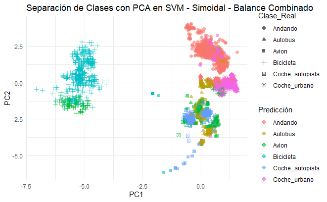

```r
library(ggplot2)

# Generar predicciones en los datos de prueba
pred <- predict(svm_model_sigmoid, test_data)

# Asegurar que test_data solo tiene variables numéricas antes de PCA
test_data_numeric <- test_data %>%
  select(-ActivityType) %>%
  mutate_if(is.character, as.numeric)  # Convertir caracteres a numéricos si hay errores

# Aplicar PCA a los datos de prueba
pca_result <- prcomp(scale(test_data_numeric))

# Crear un dataframe con los resultados del PCA y las predicciones del modelo
pca_data <- data.frame(
  PC1 = pca_result$x[, 1],
  PC2 = pca_result$x[, 2],
  Predicción = pred,  # Agregamos la predicción del modelo
  Clase_Real = test_data$ActivityType  # Agregamos la clase real
)

# Graficar la separación de clases usando PCA (según la predicción del modelo)
ggplot(pca_data, aes(x = PC1, y = PC2, color = Predicción, shape = Clase_Real)) +
  geom_point(alpha = 0.6, size = 2) +
  labs(title = "Separación de Clases con PCA en SVM - Simoidal - Balance Combinado",
       x = "PC1",
       y = "PC2") +
  theme_minimal()
```

## 4.2 Búsqueda del mejor parámetro.

Durante el proceso de ajuste de hiperparámetros del modelo SVM con kernel sigmoidal, se enfrentó un desafío técnico al realizar la búsqueda de hiperparámetros en **R**. Aunque R es un lenguaje robusto para la ciencia de datos, en este caso, la búsqueda de parámetros como **C** y **gamma** a través de validación cruzada resultó ser muy costosa en términos de recursos. A medida que aumentaba el número de combinaciones de parámetros y el tamaño del conjunto de datos, el proceso se volvió extremadamente lento, llegando a esperar hasta **3 horas** por resultados sin obtener éxito. En muchos casos, el sistema colapsaba debido a la gran demanda de memoria y procesamiento, lo que hacía que la operación fuera insostenible.

Este inconveniente fue causado por la falta de optimización de R en cuanto a la paralelización de tareas y la gestión de memoria al realizar búsquedas exhaustivas de hiperparámetros. R no logró manejar de manera eficiente la carga computacional derivada de la validación cruzada con múltiples combinaciones de parámetros, lo que resultó en un tiempo de espera largo y un sistema inestable. Esto demostró que R no era la mejor opción en este caso específico, dado que la operación estaba limitando el progreso del análisis.

Por lo tanto, se decidió cambiar a **Python**, conocido por su eficiencia y capacidad de manejar grandes volúmenes de datos y operaciones paralelizadas. Python, con bibliotecas como **scikit-learn** y **joblib**, permite la distribución de tareas entre múltiples núcleos de procesamiento, lo que optimiza significativamente el tiempo de cálculo. Gracias a estas capacidades de optimización, la búsqueda de hiperparámetros se completó con éxito y en tiempos mucho más cortos, permitiendo obtener los mejores parámetros para el modelo de manera estable y sin colapsos en el sistema. Esto hizo que Python fuera la opción ideal para realizar la tarea de manera eficiente y escalable.

Una vez obtenidos los mejores hiperparámetros en Python, se utilizaron en **R** para verificar los resultados y garantizar que los parámetros seleccionados también fueran efectivos al replicar el análisis en dicho entorno.

```r
library(e1071)

# Definir hiperparámetros
best_C <- 10
best_gamma <- 0.1


# Capturar tiempo de inicio del entrenamiento
start_train_time <- Sys.time()

# Entrenar el modelo SVM con kernel sigmoide
svm_model_sigmoid_10 <- svm(ActivityType ~ .,
                         data = train_data,
                         kernel = "sigmoid",
                         cost = best_C,
                         gamma = best_gamma,
                         class.weights = class_weights_combined,
                         probability = TRUE)

# Capturar tiempo de finalización del entrenamiento
end_train_time <- Sys.time()
train_duration <- end_train_time - start_train_time

# Imprimir tiempo de entrenamiento
print(paste("Tiempo de entrenamiento:", train_duration))
```

```
[1] "Tiempo de entrenamiento: 4.80376100540161"
```

```r
# Capturar tiempo de inicio de la predicción
start_pred_time <- Sys.time()

# Hacer predicciones con el modelo SVM Sigmoide
predictions_10 <- predict(svm_model_sigmoid_10, test_data, probability = TRUE)

# Capturar tiempo de finalización de la predicción
end_pred_time <- Sys.time()

# Calcular la duración de la predicción
pred_duration <- end_pred_time - start_pred_time

# Imprimir el tiempo de predicción
print(paste("Tiempo de predicción:", pred_duration))
```

```
[1] "Tiempo de predicción: 0.247222900390625"
```

```r
# Matriz de confusión
conf_matrix_10 <- confusionMatrix(predictions_10, test_data$ActivityType)
print(conf_matrix)
```

```
Confusion Matrix and Statistics

                 Reference
Prediction        Andando Autobus Avion Bicicleta Coche_autopista Coche_urbano
  Andando             823     170     0         0               0           61
  Autobus               0     365    26         0               0            0
  Avion                 0       0    55         0               1            0
  Bicicleta             0       0     6       597               0            0
  Coche_autopista       0       0    34         0             347            0
  Coche_urbano        172       0    42         0               0         2397

Overall Statistics

               Accuracy : 0.8995
                 95% CI : (0.8909, 0.9077)
    No Information Rate : 0.4823
    P-Value [Acc > NIR] : < 2.2e-16

                  Kappa : 0.8534

 Mcnemar's Test P-Value : NA

Statistics by Class:

                     Class: Andando Class: Autobus Class: Avion Class: Bicicleta Class: Coche_autopista Class: Coche_urbano
Sensitivity                  0.8271        0.68224      0.33742           1.0000                0.99713              0.9752
Specificity                  0.9437        0.99430      0.99980           0.9987                0.99284              0.9189
Pos Pred Value               0.7808        0.93350      0.98214           0.9900                0.91076              0.9180
Neg Pred Value               0.9574        0.96387      0.97857           1.0000                0.99979              0.9755
Prevalence                   0.1953        0.10498      0.03199           0.1172                0.06829              0.4823
Detection Rate               0.1615        0.07162      0.01079           0.1172                0.06809              0.4704
Detection Prevalence         0.2068        0.07673      0.01099           0.1183                0.07476              0.5124
Balanced Accuracy            0.8854        0.83827      0.66861           0.9993                0.99498              0.9470
```

```r
# Extraer métricas específicas
precision <- conf_matrix_10$byClass[, "Pos Pred Value"]  # Precisión por clase
recall <- conf_matrix_10$byClass[, "Sensitivity"]        # Recall por clase
f1_score <- 2 * (precision * recall) / (precision + recall)  # F1-score

# 📌 Mostrar resultados de precisión, recall y F1-score
metrics_results <- data.frame(Class = levels(test_data$ActivityType),
                              Precision = precision,
                              Recall = recall,
                              F1_Score = f1_score)

print(metrics_results)
```

|  | Class | Precision | Recall | F1_Score |
| --- | --- | --- | --- | --- |
| Class: Andando | Andando | 0.9447791 | 0.9457286 | 0.9452536 |
| Class: Autobus | Autobus | 0.9242958 | 0.9813084 | 0.9519492 |
| Class: Avion | Avion | 0.9642857 | 0.6625767 | 0.7854545 |
| Class: Bicicleta | Bicicleta | 0.9786885 | 1.0000000 | 0.9892295 |
| Class: Coche_autopista | Coche_autopista | 1.0000000 | 0.9942529 | 0.9971182 |
| Class: Coche_urbano | Coche_urbano | 0.9780844 | 0.9804719 | 0.9792767 |

```r
NA
```

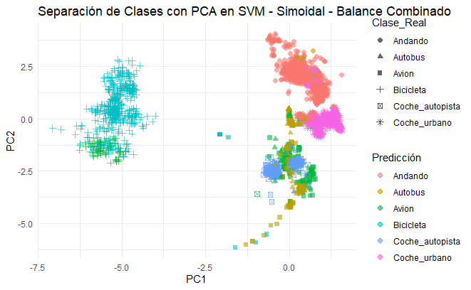

```r
library(ggplot2)

# Generar predicciones en los datos de prueba
pred <- predict(svm_model_sigmoid_10, test_data)

# Asegurar que test_data solo tiene variables numéricas antes de PCA
test_data_numeric <- test_data %>%
  select(-ActivityType) %>%
  mutate_if(is.character, as.numeric)  # Convertir caracteres a numéricos si hay errores

# Aplicar PCA a los datos de prueba
pca_result <- prcomp(scale(test_data_numeric))

# Crear un dataframe con los resultados del PCA y las predicciones del modelo
pca_data <- data.frame(
  PC1 = pca_result$x[, 1],
  PC2 = pca_result$x[, 2],
  Predicción = pred,  # Agregamos la predicción del modelo
  Clase_Real = test_data$ActivityType  # Agregamos la clase real
)

# Graficar la separación de clases usando PCA (según la predicción del modelo)
ggplot(pca_data, aes(x = PC1, y = PC2, color = Predicción, shape = Clase_Real)) +
  geom_point(alpha = 0.6, size = 2) +
  labs(title = "Separación de Clases con PCA en SVM - Simoidal - Balance Combinado",
       x = "PC1",
       y = "PC2") +
  theme_minimal()
```

En el proceso de desarrollo del modelo para la clasificación del tipo de transporte, se utilizaron dos lenguajes de programación, **Python** y **R**, con el fin de implementar el modelo de **Máquinas de Vectores de Soporte (SVM)** con un **kernel sigmoidal**. Sin embargo, los resultados obtenidos en ambos lenguajes presentaron diferencias significativas, especialmente en cuanto al **accuracy** y las **métricas de rendimiento**.

#### **Diferencias en el Rendimiento entre R y Python**

El modelo de **SVM con kernel sigmoidal** mostró diferencias de rendimiento entre **R** y **Python** debido a varios factores. En **Python**, la **búsqueda de hiperparámetros** con **`GridSearchCV`** y el **balanceo automático de clases** mediante `class_weight='balanced'` optimizaron el rendimiento, lo que resultó en un **accuracy del 100%** tanto en los datos de entrenamiento como en los de prueba. Además, la capacidad de **paralelización** y optimización de **scikit-learn** permitió un ajuste eficiente.

En resumen, **Python** ofreció una ventaja significativa en términos de optimización, manejo de recursos y herramientas avanzadas, lo que permitió obtener mejores resultados en este caso.

[figure not shown]